# Regresion lineal simple

Kenneth Roy Cabrera Torres

3 de octubre de 2018

## Fundamentación de la regresión lineal simple.

Se tiene una variable $x$ denominada explicativa, regresora o independiente y una variable $y$ denominada respuesta, regresada o dependiente.

Al tener un conjunto de pares de elementos de $x$ y $y$ se pretende construir un modelo que relacione de manera lineal y mediante una línea recta el comportamiento medio de $y$ dado los valores de $x$.

Es decir se trata de hallar los valores de $\beta_0$ y $\beta_1$ tal que puedan representar el siguiente sistema de ecuaciones:

$$\begin{eqnarray}
y_1 & = & \beta_0 + \beta_1 x_1 + \epsilon_1 \\
y_2 & = & \beta_0 + \beta_1 x_2 + \epsilon_2 \\
\vdots & = & \vdots \\
y_i & = & \beta_0 + \beta_1 x_i + \epsilon_i \\
\vdots & = & \vdots \\
y_n & = & \beta_0 + \beta_1 x_n + \epsilon_n \\
\end{eqnarray}$$

Donde el supesto más utilizado sobre los errores es:

$$e_i \sim \mathcal{N}(0, \sigma^2)$$
Donde $\sigma^2$ el la varianza de los errores aleatorios.

En forma matricial se puede escribir:

$$Y = X\beta + \epsilon$$

Donde:

$$Y = \left[
\begin{matrix}
y_1 \\
y_2 \\
\vdots \\
y_i \\
\vdots \\
y_n
\end{matrix}
\right],
\qquad
X = \left[
\begin{matrix}
1 & x_1 \\
1 & x_2 \\
\vdots \\
1 & x_i \\
\vdots \\
1 & x_n
\end{matrix}
\right],
\qquad
\beta = \left[
\begin{matrix}
\beta_0 \\
\beta_1 \\
\end{matrix}
\right],
\qquad
\epsilon = \left[
\begin{matrix}
\epsilon_1 \\
\epsilon_2 \\
\vdots \\
\epsilon_i \\
\vdots \\
\epsilon_n
\end{matrix}
\right]$$

Recordemos que la solución mínimo cuadrática para obtener los valores de $\beta$ es:

$$X'Y = X'X\beta$$

Al despejar el valor de $\beta$ se tiene que:

$$\begin{eqnarray}
X'Y & = & X'X\beta \\
(X'X)^{-1}X'Y & = & (X'X)^{-1}(X'X)\beta \\
(X'X)^{-1}X'Y & = & I\beta \\
(X'X)^{-1}X'Y & = & \beta \\
\end{eqnarray}$$

Es decir que el estimador mínimo cuadrático para $\beta$ es:

$$\hat{\beta} = (X'X)^{-1}X'Y$$

Luego el valor estimado de $Y$, es decir $\hat{Y}$ es:

$$\hat{Y} = X\hat{\beta} = X(X'X)^{-1}X'Y$$

A la matrix que toma los valores de $Y$ y obtiene los valores de $\hat{Y}$ se le denomina la matriz “hat” o sombrero y se denota por $H$.

$$H = X(X'X)^{-1}X'$$

Esta matriz tiene propiedades para identificar valores influenciales de los datos de $X$.

## Ejemplo con el pez Longnose dace (*Rhinichthys cataractae*).

El pecesito Langnose dace (*Rhinichthys cataractae*) habita en la corrientes de agua de Norteamérica.

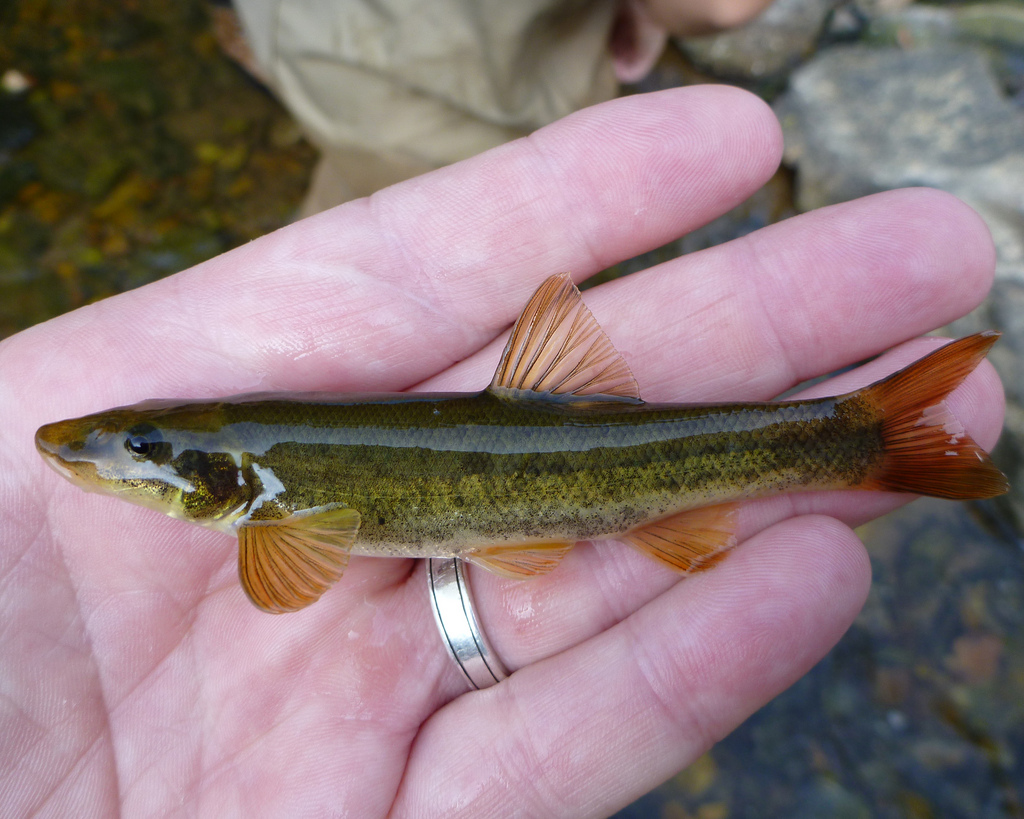

En la [página del John H. McDonald](http://www.biostathandbook.com/multipleregression.html) se encuentra una base de datos que el investigador menciona que fue tomada del sito del [Maryland Biological Stream Suervey](http://dnr.maryland.gov/streams/Pages/mbss.aspx).

El MBSS realiza unos muestreos siguiendo un protocolo establecida para determinar la abundancia de peces en un tramo de la quebrada de 75 metros.

La base de datos tiene las siguientes columanas:

- quebrada: Nombre de la quebrada muestreada.
- num_indiv: Número de individuos contados en un tramo de 75 m.
- area: El área (en acres) drenada por la quebrada hasta el punto de muestreo.
- oxi_dis: El oxigeno disuelto (en mg/litro).
- prof_max: Profundidad máxima (en cm) del tramo de 75 metros.
- nitrato: Concentración de nitrato en (mg/litro).
- sulfato: Concentración de sulfato en (mg/litro).
- temperatura: La temperatura (en grados centígrados) de la quebrada en el fecha de muestreo.

El interés es conocer e identificar las variables que influencian en la abundancia del pecesito.

Y constuir un modelo que permita estimar la abundancia esperada dada las características ambientales de la quebrada.

```r
library(tidyverse)
```

### Lectura de la base de datos.

```r
longnose <- read.table("datos_Longnose.txt", header = TRUE)
```

### Construcción del área drenada en Km$^2$.

Hay 0.00404685642 Km$^2$ en un acre.

```r
longnose <- longnose %>%
            mutate(areaKm2 = area * 0.00404685642)
```

```r
longnose
```

```
##                    quebrada num_indiv  area oxi_dis prof_max nitrato sulfato temperatura    areaKm2
## 1                 BASIN_RUN        13  2528     9.6       80    2.28   16.75        15.3  10.230453
## 2                   BEAR_BR        12  3333     8.5       83    5.34    7.74        19.4  13.488172
## 3                   BEAR_CR        54 19611     8.3       96    0.99   10.92        19.5  79.362901
## 4             BEAVER_DAM_CR        19  3570     9.2       56    5.44   16.53        17.0  14.447277
## 5                BEAVER_RUN        37  1722     8.1       43    5.66    5.91        19.3   6.968687
## 6                BENNETT_CR         2   583     9.2       51    2.26    8.81        12.9   2.359317
## 7                    BIG_BR        72  4790     9.4       91    4.10    5.65        16.7  19.384442
## 8                BIG_ELK_CR       164 35971    10.2       81    3.20   17.53        13.8 145.569472
## 9               BIG_PIPE_CR        18 25440     7.5      120    3.53    8.20        13.7 102.952027
## 10            BLUE_LICK_RUN         1  2217     8.5       46    1.20   10.85        14.3   8.971881
## 11                BROAD_RUN        53  1971    11.9       56    3.25   11.12        22.2   7.976354
## 12              BUFFALO_RUN        16 12620     8.3       37    0.61   18.87        16.8  51.071328
## 13                  BUSH_CR        32 19046     8.3      120    2.93   11.31        18.0  77.076427
## 14            CABIN_JOHN_CR        21  8612     8.2      103    1.57   16.09        15.0  34.851527
```

[output cut: 54 more lines]

### Matriz de diagramas de dispersión.

```r
## Función auxiliar para constuir un histograma en la diagonal de
## la matriz de dispersión tomado de la ayuda de comando `pairs()`.
panel.hist <- function(x, ...)
{
    usr <- par("usr"); on.exit(par(usr))
    par(usr = c(usr[1:2], 0, 1.5) )
    h <- hist(x, plot = FALSE)
    breaks <- h$breaks; nB <- length(breaks)
    y <- h$counts; y <- y/max(y)
    rect(breaks[-nB], 0, breaks[-1], y, col = "cyan", ...)
}
```

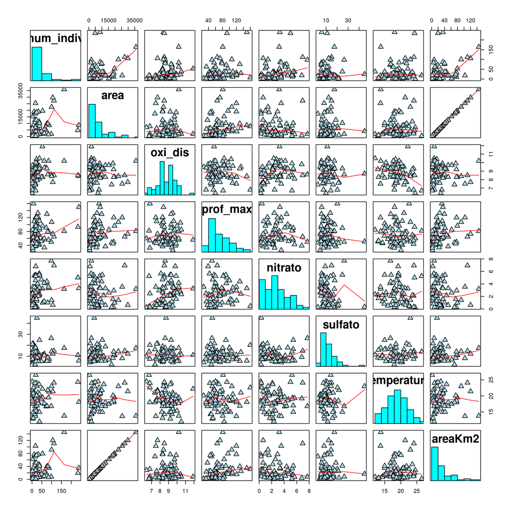

```r
pairs(longnose[, -1], panel = panel.smooth,
      cex = 1.5, pch = 24, bg = "light blue",
      diag.panel = panel.hist, cex.labels = 2, font.labels = 2)
```

En particula se examinará el comportamiento de la abundancia del pecesito tomando en cuenta el área drenada hasta el sitio de muestreo.

### Diagrama de dispersión de la abundancia vs el área drenada.

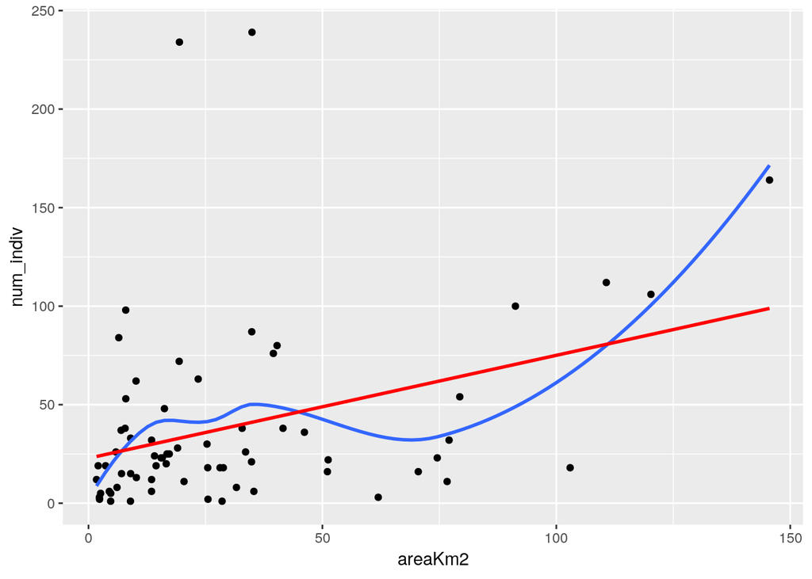

```r
ggplot(longnose, aes(areaKm2, num_indiv)) +
  geom_point() +
  geom_smooth(se = FALSE) +
  geom_smooth(method = lm, se = FALSE, col = "red")
```

### Estimación de los parámetros de regresión lineal simple.

```r
Y <- as.matrix(longnose[, 2])
X <- as.matrix(cbind(1, longnose[, "areaKm2"]))

beta <-  solve(t(X) %*% X) %*% t(X) %*% Y
beta
```

```
##           [,1]
## [1,] 22.818155
## [2,]  0.522332
```

### Estimación del valor esperado de abundancia por cada quebrada.

```r
Y_est <- X %*% beta
Y_est
```

```
##           [,1]
##  [1,] 28.16185
##  [2,] 29.86346
##  [3,] 64.27194
##  [4,] 30.36443
##  [5,] 26.45812
##  [6,] 24.05050
##  [7,] 32.94327
##  [8,] 98.85375
##  [9,] 76.59330
## [10,] 27.50446
## [11,] 26.98446
## [12,] 49.49435
## [13,] 63.07764
## [14,] 41.02222
```

[output cut: 54 more lines]

## Simulación de regresión lineal simple.

Para tener una estimación del temaño de muestra adecuado se requiere suponder loa valores “verdaderos” de $\beta_0$ y $\beta_1$ como también un valor de la varianza del error aleatorio $\sigma^2$.

También se necesita determinar si el valor de $X$ es aleatorio o son valores fijos.

En este contexto en particular los valores de $x$ son aleatorios.

### Distribución de los valores aleatorios de X.

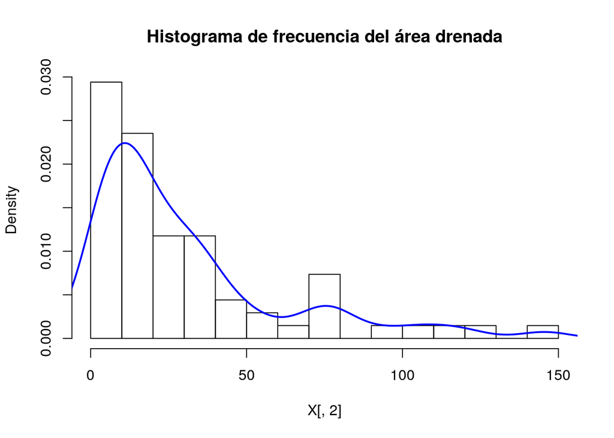

```r
hist(X[, 2], nclass = 18,
     main = "Histograma de frecuencia del área drenada",
     freq = FALSE)
lines(density(X[, 2]), col = "blue", lwd = 2)
```

Para la simulación se tomarán valores aleatorios de los datos originales con reemplazamiento de las áreas drenadas.

### Determinación de los valores de la desviación estándar de los errores.

```r
segmentosX <- cut(X[, 2], seq(0, 160, 10))
desv_estandard <- tapply(Y, segmentosX, sd)
desv_estandard
```

```
##    (0,10]   (10,20]   (20,30]   (30,40]   (40,50]   (50,60]   (60,70]   (70,80]   (80,90]  (90,100]
## 27.152590 54.263401 19.737112 77.230522 24.846194  4.242641        NA 16.932218        NA        NA
## (100,110] (110,120] (120,130] (130,140] (140,150] (150,160]
##        NA        NA        NA        NA        NA        NA
```

```r
desv_est_estim <- mean(desv_estandard, na.rm = TRUE)
desv_est_estim
```

```
## [1] 32.05781
```

### Parámetros de simulación.

Se tiene entonces que:

- Los valores de $x$ son aleatorios.
- $\beta_0$ = 23
- $\beta_1$ = 0.5
- $\sigma$ = 32, luego $\sigma^2$ = 1024.

```r
beta0 <- 23
beta1 <- 0.5
sigma <- 32
sigma2 <- sigma ^ 2
```

```r
# Para hacer la simulación reproducible.
# set.seed(0)
```

```r
tam_muestra <- 50
```

```r
x <- sort(sample(X[, 2], tam_muestra,  replace = TRUE))
y <- beta0 + beta1 * x
e <- rnorm(tam_muestra, 0, sigma)
y <- y + e
y <- as.integer(round(y, 0))

# Los valores de y < 0 se remplazarán por 0
y[y < 0] <- 0

datos <- data.frame(x = x, y =  y)
```

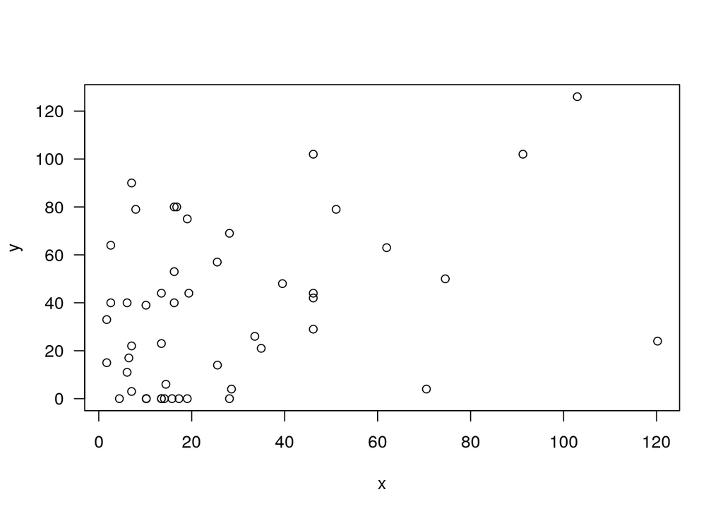

```r
plot(datos, las = 1)
```

```r
Y <- as.matrix(datos$y)
X <- as.matrix(cbind(1, datos$x))
```

```r
betas_est <- solve(t(X) %*% X) %*% t(X) %*% Y
betas_est
```

```
##            [,1]
## [1,] 23.6837518
## [2,]  0.4606606
```

```r
est_param <- function(datos) {
  Y <- as.matrix(datos[, "y"])
  X <- as.matrix(cbind(1 , datos[, "x"]))
  beta_est <- solve(t(X) %*% X) %*% t(X) %*% Y
  return(beta_est)
}
```

```r
est_param(datos)
```

```
##            [,1]
## [1,] 23.6837518
## [2,]  0.4606606
```

```r
gen_datos <- function(tam_muestra, beta0, beta1, sigma, x_orig){
   x <- sort(sample(x_orig, tam_muestra,  replace = TRUE))
   y <- beta0 + beta1 * x
   e <- rnorm(tam_muestra, 0, sigma)
   y <- y + e
   y <- as.integer(round(y, 0))
   # Los valores de y < 0 se remplazarán por 0
   y[y < 0] <- 0
   datos <- cbind(x = x, y =  y)
   return(datos)
}
```

```r
numsim <- 5000
tam_muestra <- 10
vector_tam_m <- rep(tam_muestra, numsim)
datosT <- lapply(vector_tam_m, gen_datos,
                 beta0 = beta0,
                 beta1 = beta1,
                 sigma = sigma,
                 x_orig = longnose$areaKm2)
```

```r
datosT[1:3]
```

```
## [[1]]
##                x  y
##  [1,]   1.715867  0
##  [2,]  13.476032  0
##  [3,]  16.231941 34
##  [4,]  19.044506 13
##  [5,]  19.384442 17
##  [6,]  28.121605 68
##  [7,]  31.622136 60
##  [8,]  32.840240 46
##  [9,]  32.840240 14
## [10,] 145.569472 76
##
## [[2]]
##                x  y
```

[output cut: 23 more lines]

```r
parametros <- sapply(datosT, est_param)
parametros[, 1:5]
```

```
##            [,1]       [,2]       [,3]       [,4]      [,5]
## [1,] 17.0578387 21.0705372 13.3631139 25.0368123 7.1233477
## [2,]  0.4618549  0.4248598  0.6822603  0.4955086 0.7652985
```

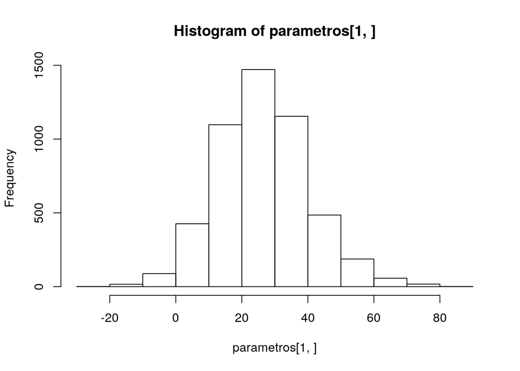

```r
hist(parametros[1, ])
```

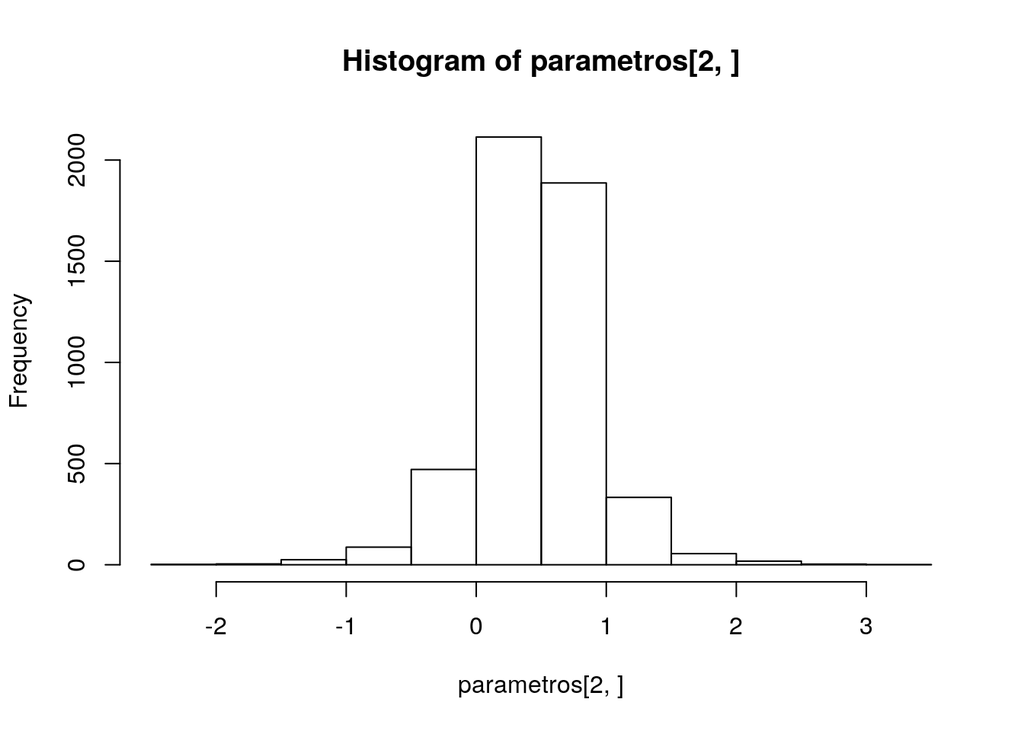

```r
hist(parametros[2, ])
```

### Determinación del grado de precisión.

```r
nivel_significancia <- 0.05
IC <- quantile(parametros[2, ],
               c(nivel_significancia/2, (1-nivel_significancia/2)))
IC
```

```
##       2.5%      97.5%
## -0.4599897  1.3014837
```

```r
IC - beta1
```

```
##       2.5%      97.5%
## -0.9599897  0.8014837
```